# Vendor Performance Analysis

Fatima Zehra

## 1. Introduction

This project is part of the Google Data Analytics Professional Certificate.  
The goal is to analysis is to evaluate vendor performance using transactional purchase, sales, pricing, and invoice data in order to support strategic decision-making.

This analysis aims to evaluate vendor performance and procurement concentration using purchase and sales data, with a focus on identifying key vendors that drive the majority of spend and assessing diversification risk.

## 2. Data Import and Audit

The analysis uses a cleaned and aggregated vendor-level dataset prepared during the data processing stage.

## 3. Data Quality and Sanity Checks

Data quality checks identified missing values in sales- and margin-related fields. Missing values were reviewed based on their business context, while records failing the defined business rules were excluded from the final analytical dataset.

```
## Rows: 10450
```

```
## Columns: 18
```

### 3.1 Data Filtering | Business Rules

To ensure the analysis focuses on valid and profitable vendor activity, records were filtered using the following business rules:

- Gross Profit > 0
- Profit Margin > 0
- Total Sales Quantity > 0

```
## Rows: 8533
```

```
## Columns: 18
```

## 4. Exploratory Data Analysis

Exploratory Data Analysis (EDA) was conducted to understand overall purchasing and sales patterns. The purpose of this section is to highlight key trends, not to document every intermediate plot created during exploration.

### 4.1 Correlation

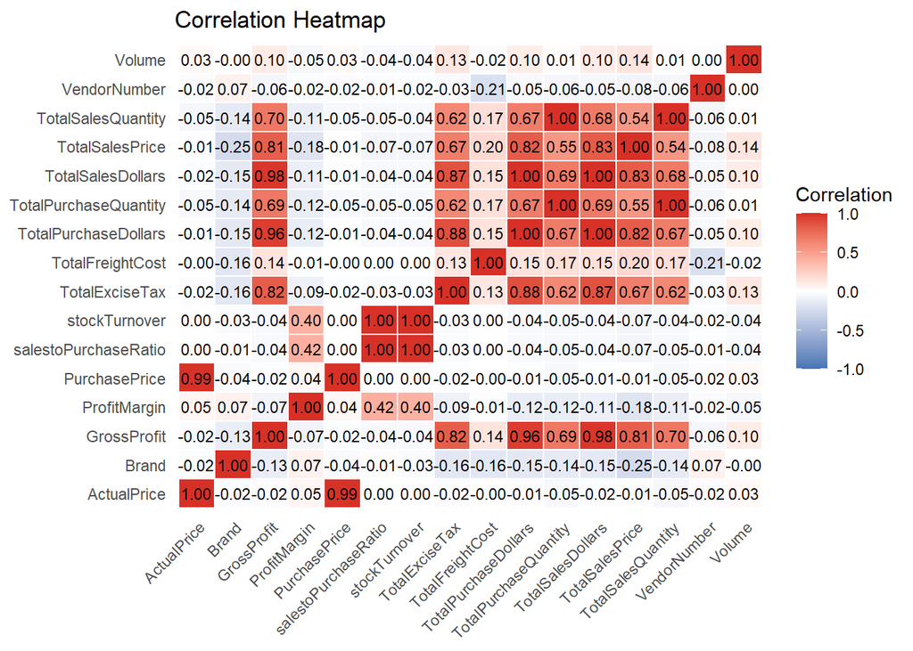

### Insight:

**Purchase Price vs. Total Sales Dollars & Gross Profit:** Weak correlation (-0.012 and -0.016), indicating that price variations do not significantly impact sales revenue or profit.

**Total Purchase Quantity vs. Total Sales Quantity:** Strong positive correlation (0.999), indicating that vendors with higher purchase quantities also tend to have higher sales quantities.

**Profit Margin vs. Total Sales Price:** Weak negative correlation (-0.179), indicating a slight inverse relationship between sales price and profit margin in the analyzed data.

### 4.2 Distribution of Purchase Spend

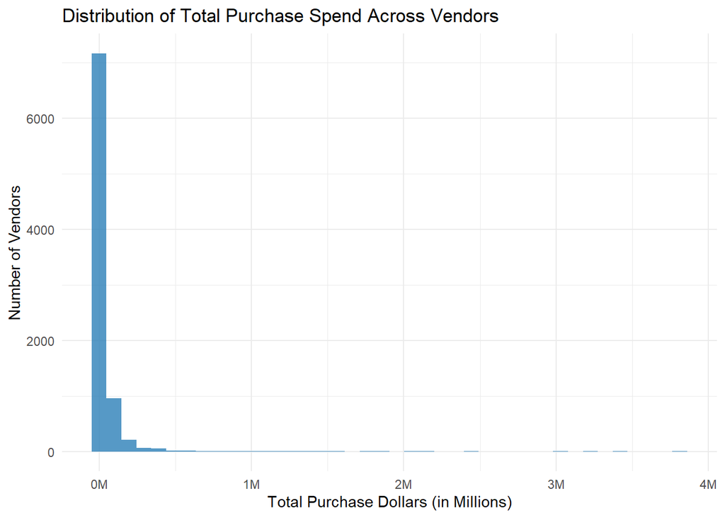

### Insight:

The distribution of total purchase spend is highly right-skewed, indicating that a small number of vendors account for a disproportionately large share of total purchases. This suggests vendor concentration and highlights the importance of identifying key contributors to overall procurement spend.

### 4.3 Sales vs Profit Relationship

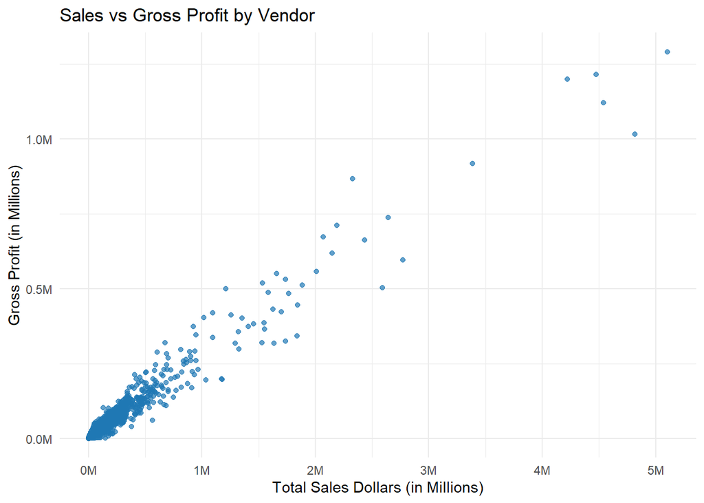

### Insight:

There is a general positive relationship between total sales and gross profit; however, several vendors exhibit high sales with comparatively lower profit levels. This indicates variability in vendor profitability and suggests that high sales volume does not always translate into strong margins.

### 4.4 Brands for Promotional or Pricing Adjustment

```
## [1] "Brands with Low Sales but High Profit Margins:"
```

```
## # A tibble: 198 × 4
##    Description                  TotalSalesDollars ProfitMargin .group
##    <chr>                                    <dbl>        <dbl> <chr>
##  1 Santa Rita Organic Svgn Bl                9.99         66.5 drop
##  2 Debauchery Pnt Nr                        11.6          66.0 drop
##  3 Concannon Glen Ellen Wh Zin              16.0          83.4 drop
##  4 Crown Royal Apple                        27.9          89.8 drop
##  5 Sauza Sprklg Wild Berry Marg             28.0          82.2 drop
##  6 Merry Irish Cream Liqueur                36.0          73.5 drop
##  7 Tracia Syrah                             44.9          88.5 drop
##  8 Basilica Amaretto                        47.4          85.1 drop
##  9 Flag Hill Heritage Rd NH                 50.0          65.5 drop
## 10 New Amsterdam Red Berry Vdka             64.0          81.2 drop
## # ℹ 188 more rows
```

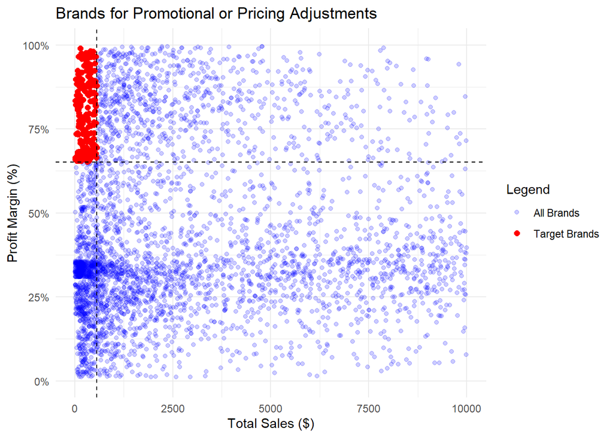

### Insight

198 brands exhibit lower sales but higher profit margins, which could benefit from targeted marketing, promotions, or price optimizations to increase volume without compromising profitability.

### 4.5 Top 10 Brands by Gross Profit

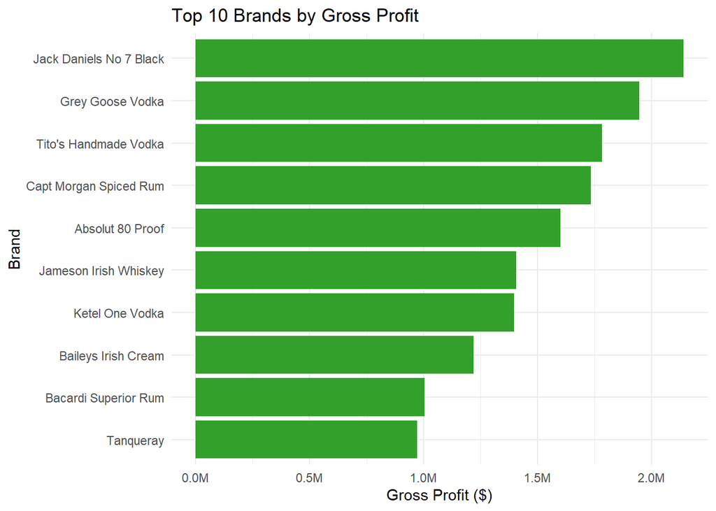

### Insight:

The top 10 brands contribute a substantial share of total gross profit, with Jack Daniels No 7 Black generating the highest profit, followed by Grey Goose Vodka and Tito’s Handmade Vodka. This indicates that profitability is concentrated among a small number of premium brands, making them strategically important for revenue growth and inventory planning.

## 5. Vendor Contribution Analysis

### Objective

The objective of this section is to identify vendors that contribute the most to total purchase dollars and to evaluate the concentration of procurement spend. This analysis supports strategic sourcing decisions, vendor prioritization, and risk assessment related to supplier dependency.

### 5.1 Vendor Purchase Contribution

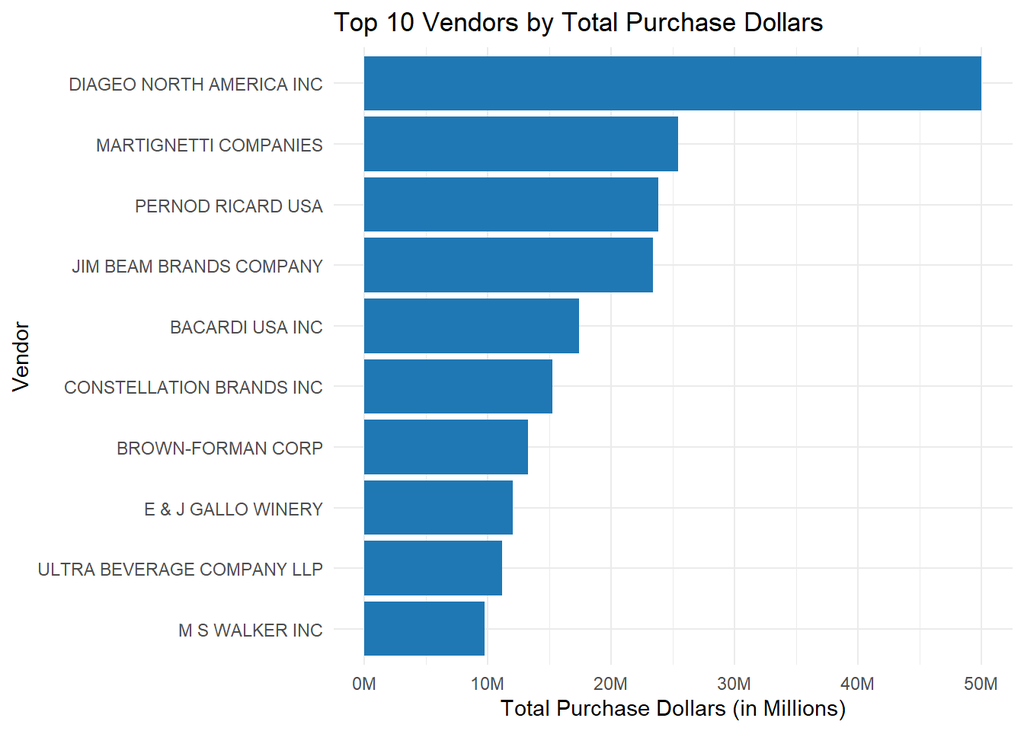

### Insight

Purchase spend is highly concentrated among a small number of vendors, with DIAGEO NORTH AMERICA INC alone accounting for the largest share of total purchase dollars by a wide margin.

The top 3–4 vendors contribute disproportionately compared to the remaining vendors, indicating strong dependence on key suppliers.

This concentration suggests that pricing changes, supply disruptions, or contract renegotiations with these vendors could materially impact overall procurement costs.

### 5.2 Pareto Analysis of Vendor Contribution

The Pareto analysis evaluates whether procurement spend follows the 80/20 principle—where approximately 80% of total purchase dollars are contributed by around 20% of vendors.

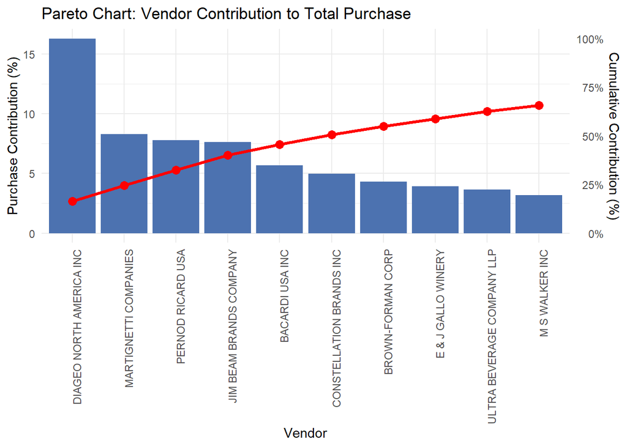

### Insight

While vendor concentration can improve negotiation leverage and operational efficiency, it also introduces supplier risk, reinforcing the need for diversified sourcing or contingency planning.

### 5.1 Methodology

Vendor-level purchase contribution was calculated as the proportion of each vendor’s total purchase dollars relative to the overall purchase volume. Vendors were ranked in descending order, and the top contributors were selected for analysis.

### 5.2 Key Visualization

A bar chart displaying the top 10 vendors by purchase contribution was used to illustrate concentration effects and relative vendor importance.

```
## # A tibble: 1 × 1
##   total
##   <dbl>
## 1  65.7
```

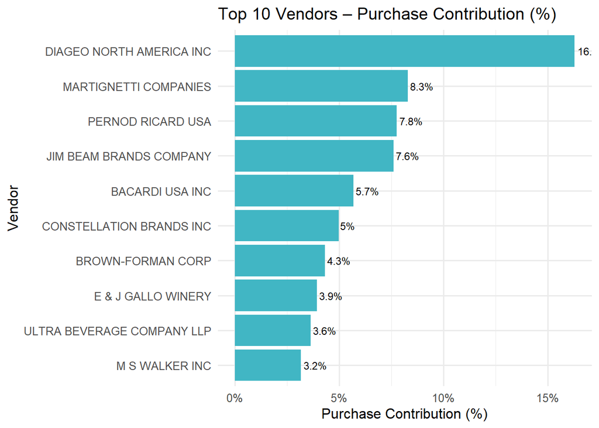

### Insight

The leading vendor contributes approximately 16% of total purchase dollars, while the remaining top vendors individually contribute between 3% and 8%.

Beyond the top vendor, contribution declines gradually, forming a long-tail distribution among vendors.

This pattern highlights an opportunity to optimize sourcing strategy, either by strengthening partnerships with high-value vendors or redistributing spend to reduce dependency risk.

### 5.3 Strategic Implications

Key business implications derived from the vendor contribution analysis include:

High dependency on a limited number of vendors increases supply chain and pricing risk.

Strategic vendors should be prioritized for contract negotiation, performance monitoring, and relationship management.

Lower-contributing vendors may present opportunities for consolidation or alternative sourcing strategies.

## 6. Conclusion

The analysis reveals a high concentration of purchasing spend among a small group of vendors, highlighting potential supplier dependency and procurement risk.

Based on these findings, the following actions are recommended:

- **Monitor dependency on top vendors** to identify and mitigate supply and procurement risks.
- **Evaluate profitability alignment** among high-contribution vendors to ensure purchasing volume supports profitable sales.
- **Explore vendor diversification** among mid-tier vendors to reduce reliance on a small number of suppliers.

## 7 Recommendations

- Re-evaluate pricing for low-sales, high-margin brands to boost sales volume without sacrificing profitability.
- Diversify vendor partnerships to reduce dependency on a few suppliers and mitigate supply chain risks.
- Leverage bulk purchasing advantages to maintain competitive pricing while optimizing inventory management.
- Optimize slow-moving inventory by adjusting purchase quantities, launching clearance sales, or revising storage strategies.
- Enhance marketing and distribution strategies for low-performing vendors to drive higher sales volumes without compromising profit margins.
- By implementing these recommendations, the company can achieve sustainable profitability, mitigate risks, and enhance overall operational efficiency.